# Simulation - Results

2025-07-28

**Set 1: Ignorable selection with a shadow variable**

OR(Y) = 1 and OR(A) = 1 –> 3 scenarios: Cor(Y,A|Z) = {0.2, 0.5, 0.8}

**Set 2: Ignorable selection without a shadow variable**

OR(Y) = 1 and OR(A) != 1 –> 6 scenarios: OR(A) = {1.1, 2} and Cor(Y,A|Z) = {0.2, 0.5, 0.8}

**Set 3: Nonignorable selection with a shadow variable**

OR(Y) != 1 and OR(A) = 1 –> 6 scenarios: OR(Y) = {1.1, 2} and Cor(Y,A|Z) = {0.2, 0.5, 0.8}

**Set 4: Nonignorable selection without a shadow variable**

OR(Y) != 1 and OR(A) != 1 –> 12 scenarios: OR(Y) = {1.1, 2} and OR(A) = {1.1, 2} and Cor(Y,A|Z) = {0.2, 0.5, 0.8}

Notes:

## Set 1: Ignorable w/Shadow Variable

OR(Y) = 1 and OR(A) = 1 –> 3 scenarios: Cor(Y,A|Z) = {0.2, 0.5, 0.8}

Methods that should be unbiased are:

- PPMM-Reg(phi=0)
- PPMM(phi=0)
- Chen methods (DR, IPW, MI)
- Shadow Variable (P)

### Bias

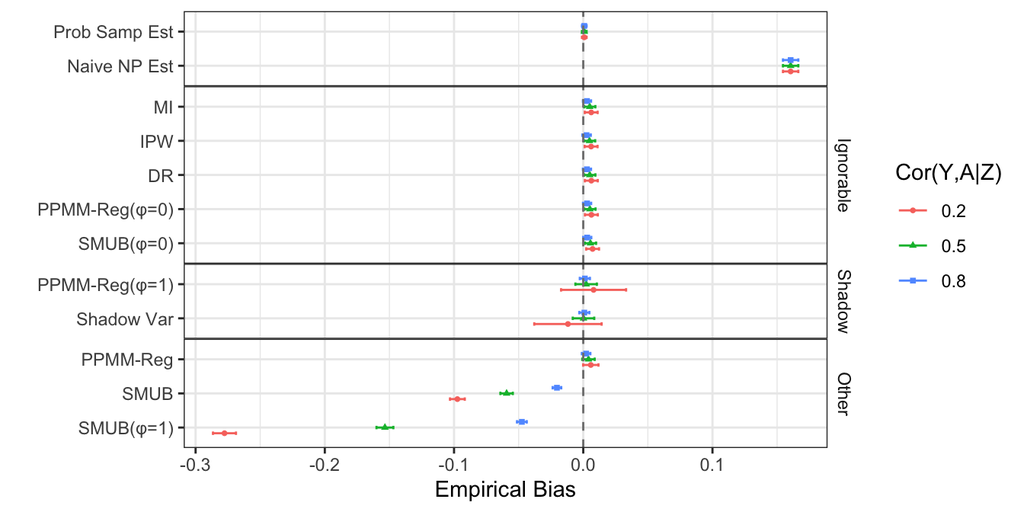

### Coverage

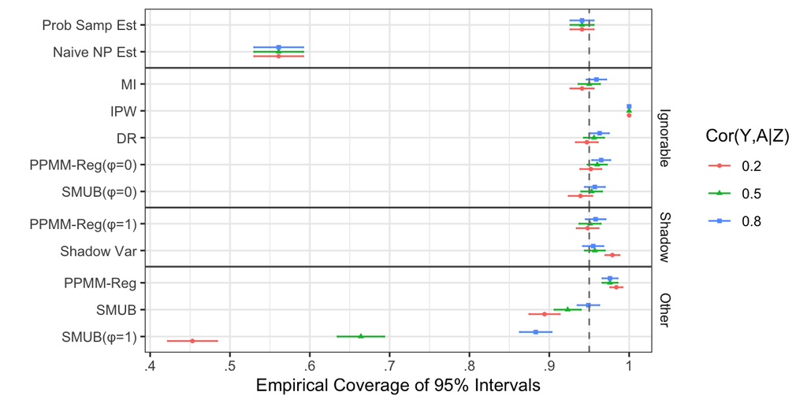

### CI Width

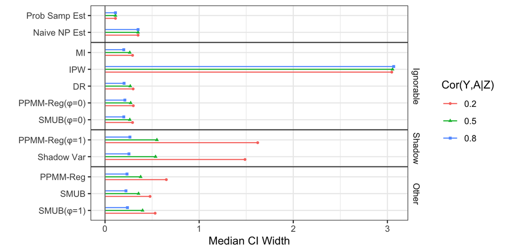

## Set 2: Ignorable w/NO Shadow Variable

OR(Y) = 1 and OR(A) != 1 –> 6 scenarios: OR(A) = {1.1, 2} and Cor(Y,A|Z) = {0.2, 0.5, 0.8}

Methods that should be unbiased are:

- PPMM-Reg(phi=0)
- PPMM(phi=0)
- Chen methods (DR, IPW, MI)

### Bias

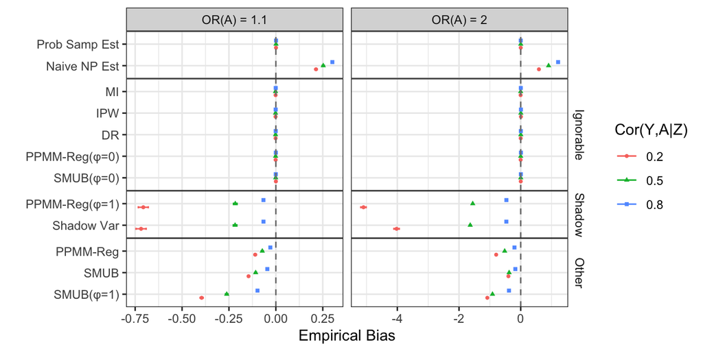

### Coverage

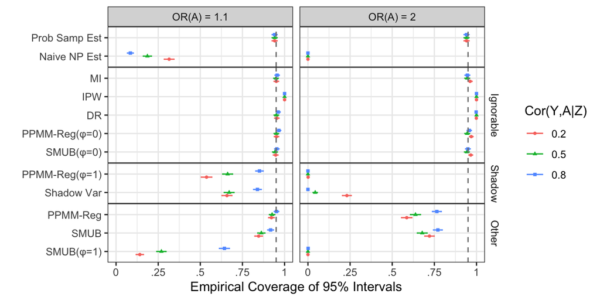

### CI Width

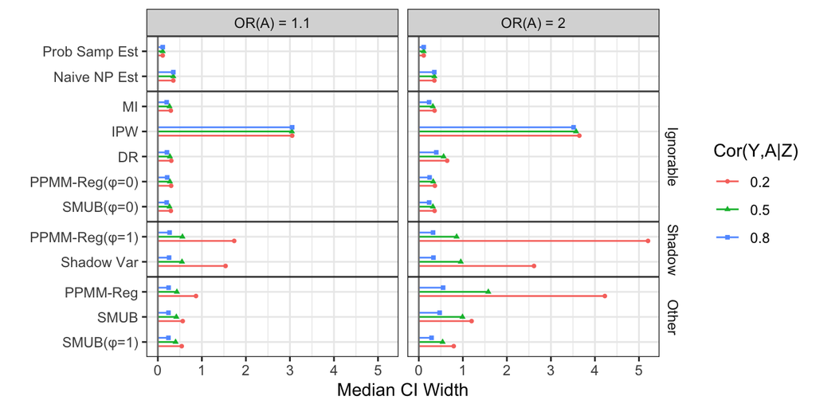

## Set 3: Non-Ignorable w/Shadow Variable

OR(Y) != 1 and OR(A) = 1 –> 6 scenarios: OR(Y) = {1.1, 2} and Cor(Y,A|Z) = {0.2, 0.5, 0.8}

Methods that should be unbiased are:

- PPMM-Reg(phi=1)
- Shadow Variable (P)

### Bias

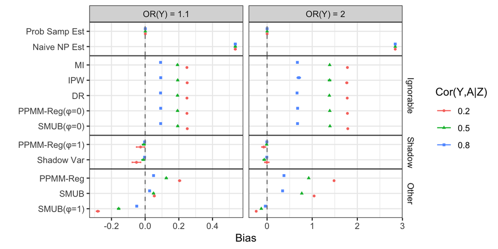

### Coverage

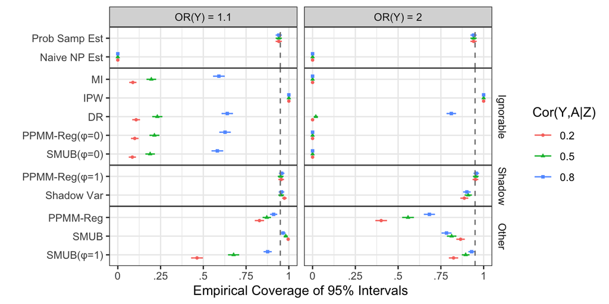

### CI Width

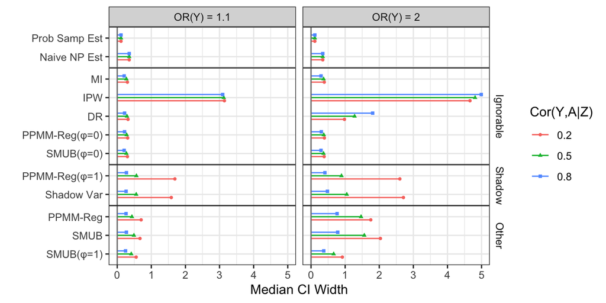

## Set 4: Non-Ignorable w/NO Shadow Variable

OR(Y) != 1 and OR(A) != 1 –> 12 scenarios: OR(Y) = {1.1, 2} and OR(A) = {1.1, 2} and Cor(Y,A|Z) = {0.2, 0.5, 0.8}

No methods will be unbiased (b/c for PPMM and PPMM-Reg the phi value will be somewhere in {0,1})

But PPMM and PPMM-Reg with uniform prior should have decent coverage

### Bias

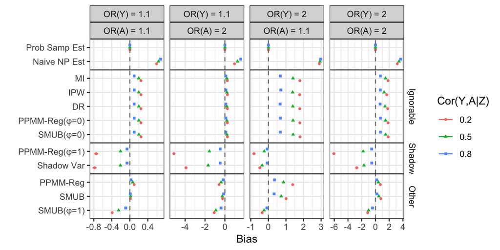

### Coverage

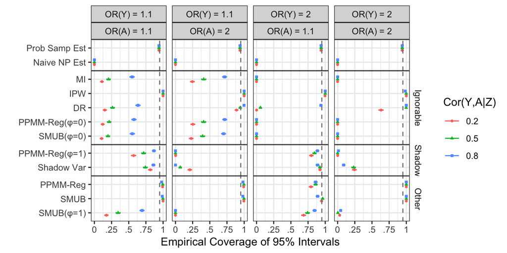

### CI Width

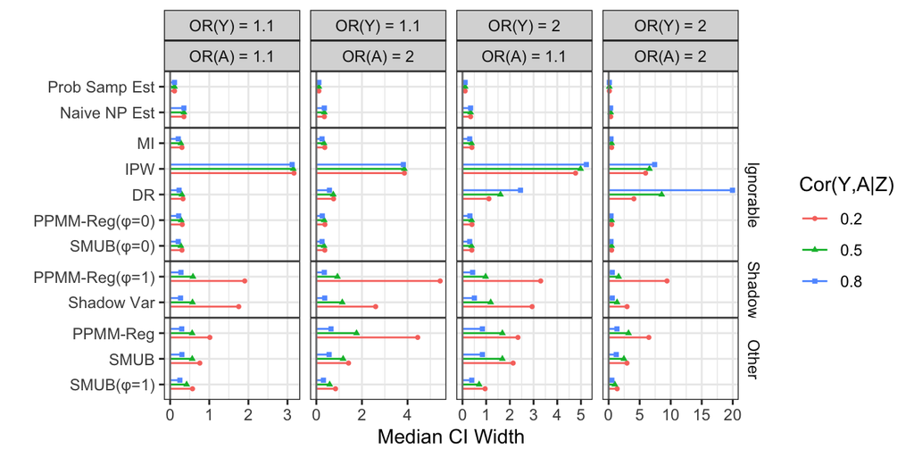